# GML Poisson

2025-11-24

## Load data

```r
bees <- read.csv("Eulaema.csv")
head(bees)
```

```
##   Eulaema_nigrita
## 1             492
## 2             372
## 3             679
## 4             600
## 5              28
## 6             535
##                                                               SA  SU   method
## 1                                                Morro_do_Itaoca 1-1 NetTraps
## 2                       Esta\xe7\xe3o_Ecol\xf3gica_de_Guaxindiba 2-1    Traps
## 3                       Esta\xe7\xe3o_Ecol\xf3gica_de_Guaxindiba 2-2    Traps
## 4                                                  Mata_do_Funil 2-3    Traps
## 5 \xc1rea_de_Prote\xe7\xe3o_Ambiental_da_Barra_do_Rio_Mamanguape 6-1      Net
## 6 \xc1rea_de_Prote\xe7\xe3o_Ambiental_da_Barra_do_Rio_Mamanguape 6-2      Net
##     effort altitude MAT  MAP Tseason Pseason    forest.    lu_het
## 1 4.189655        6 235 1073    2036      53 0.04416404 1.0531299
## 2 5.204007       17 230  987    1760      49 0.18217054 0.7571063
## 3 5.204007       17 230  987    1760      49 0.18217054 0.7571063
## 4 5.204007       30 231 1030    1820      51 0.01577287 0.8277580
## 5 4.969813        0 259 1693    1074      62 0.05000000 0.9672604
## 6 4.969813       43 255 1697    1061      63 0.05000000 0.8711333
```

## Initial plotting

Here a qqplot for the residuals could be added.

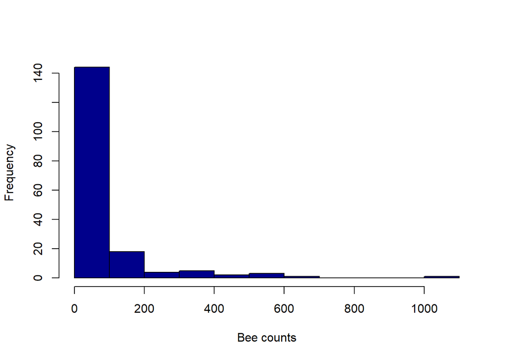

```r
hist(bees$Eulaema_nigrita, xlab = "Bee counts", main = "", col = "darkblue")
```

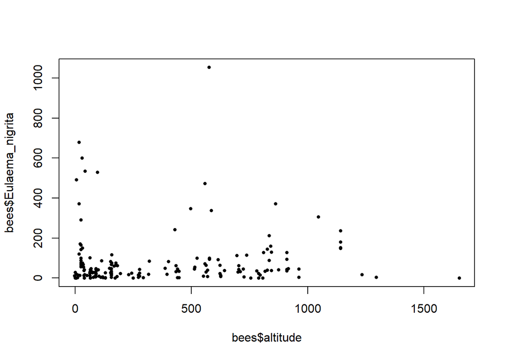

```r
plot(bees$altitude, bees$Eulaema_nigrita, pch = 16, cex = 0.6)
```

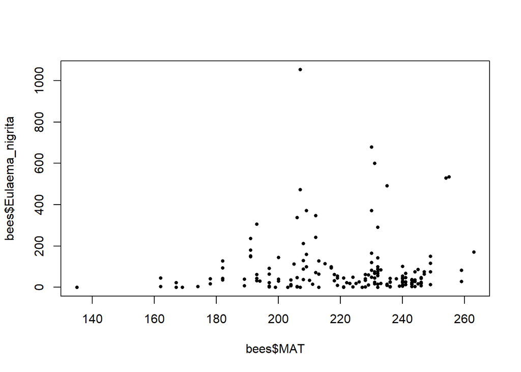

```r
plot(bees$MAT, bees$Eulaema_nigrita, pch = 16, cex = 0.6)
```

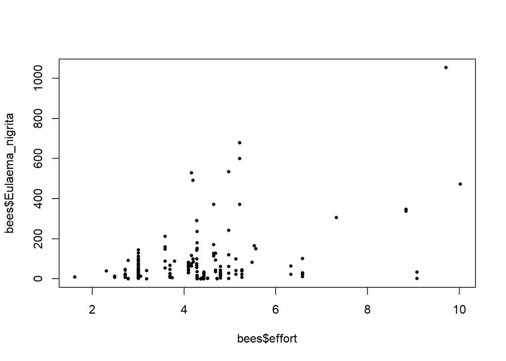

```r
plot(bees$effort, bees$Eulaema_nigrita, pch = 16, cex = 0.6)
```

From the histogram above you can see that there are no negative values (= the data is count values).

```r
# Check if there are any decimals (= non integears)
class(bees$Eulaema_nigrita)
```

```
## [1] "integer"
```

```r
# There is one very high value, check out which one that is
bees[bees$Eulaema_nigrita > 800, ]
```

```
##     Eulaema_nigrita                                       SA   SU method
## 142            1054 Permanent_Preservation_Area_Vargem_Limpa 60-1  Traps
##       effort altitude MAT  MAP Tseason Pseason forest.   lu_het
## 142 9.706012      576 207 1229    2389      62       0 1.302638
```

```r
# I notice that the altitude and the effort is extrodinary high for this sample, compared to the once in "head" above.

summary(bees$effort)
```

```
##    Min. 1st Qu.  Median    Mean 3rd Qu.    Max.
##   1.609   2.996   4.159   4.157   4.718  10.020
```

```r
summary(bees$altitude)
```

```
##    Min. 1st Qu.  Median    Mean 3rd Qu.    Max.
##    -3.0    68.0   179.0   369.3   625.0  1651.0
```

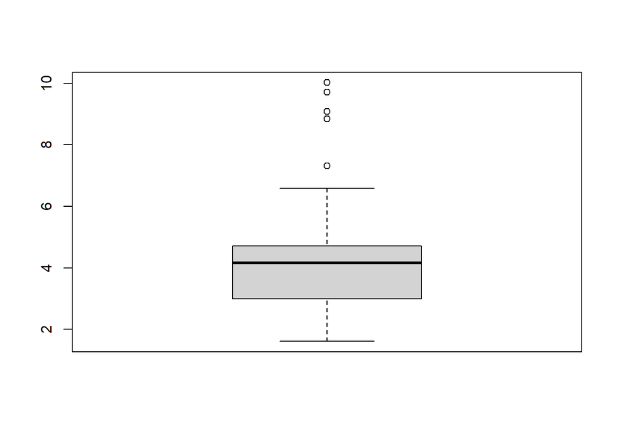

```r
boxplot(bees$effort)
```

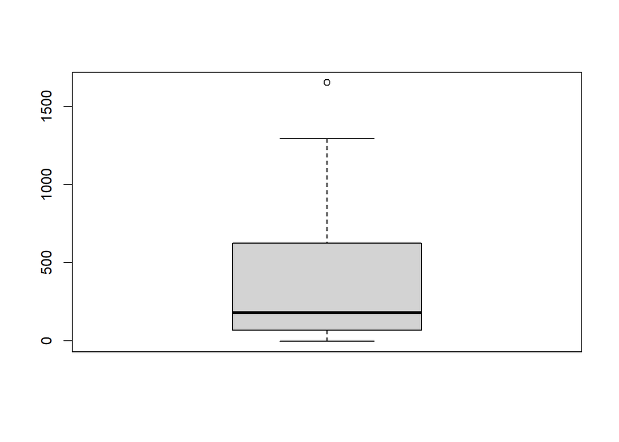

```r
boxplot(bees$altitude)
```

Since the data point (sample 142) have an extraordinary high count, but also a high altitude and high effort this might actually be a real data point. Not a mistake in putting in the numbers or similar. If all values in the row for this sample would be unusual that would also be a reason to be suspicious, but they are not. So I will continue with not removing this data point, as I belive it is real data.  
Check for over dispersion.  
Poisson assumes that the variance = mean

```r
mean(bees$Eulaema_nigrita)
```

```
## [1] 81.14045
```

```r
var(bees$Eulaema_nigrita)
```

```
## [1] 18549.07
```

So that is really bad results. I do make the poisson model anyways. And after also looking at residual deviance compared to the degrees of freedom it confirms over dispersion and then I make a negative binomial model.  
Check how many 0 counts there are, because many 0’s can effect the model results

```r
sum(bees$Eulaema_nigrita == 0)
```

```
## [1] 7
```

```r
sum(bees$Eulaema_nigrita)
```

```
## [1] 14443
```

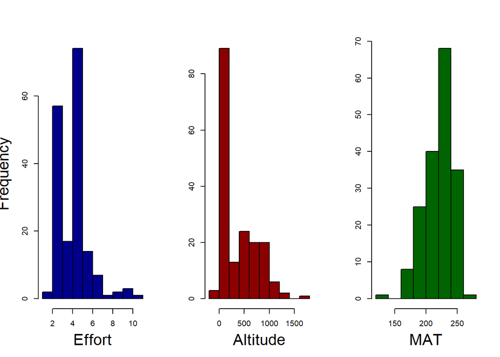

```r
par(mfrow = c(1,3))
hist(bees$effort, main = "", xlab = "Effort" , cex.lab = 2, col = "darkblue")
hist(bees$altitude, main = "", xlab = "Altitude", ylab = "", cex.lab = 2, col = "darkred")
hist(bees$MAT, main = "", xlab = "MAT", ylab = "", cex.lab = 2, col = "darkgreen" )
```

## Fit the poisson model

The model automatically transforms the data with the natural logarithm because the choose family is poisson.

```r
m = glm(Eulaema_nigrita~effort+altitude+MAT, family = "poisson", data=bees)
summary(m)
```

```
##
## Call:
## glm(formula = Eulaema_nigrita ~ effort + altitude + MAT, family = "poisson",
##     data = bees)
##
## Coefficients:
##               Estimate Std. Error z value Pr(>|z|)
## (Intercept) -1.3246665  0.1739506  -7.615 2.63e-14 ***
## effort       0.3414200  0.0039228  87.034  < 2e-16 ***
## altitude     0.0009338  0.0000449  20.799  < 2e-16 ***
## MAT          0.0171531  0.0007053  24.322  < 2e-16 ***
## ---
## Signif. codes:  0 '***' 0.001 '**' 0.01 '*' 0.05 '.' 0.1 ' ' 1
##
## (Dispersion parameter for poisson family taken to be 1)
##
##     Null deviance: 23280  on 177  degrees of freedom
## Residual deviance: 16998  on 174  degrees of freedom
## AIC: 17931
##
## Number of Fisher Scoring iterations: 6
```

We can see here that the residual deviance is 16998 and the degrees of freedom is 174. So the deviance is much larger than the degrees of freedom which means that the variance increases unproportional to the mean. Therefore we will have to use a negative binomial error distribution instead.  
## Fit negative binomal model

```r
library(MASS)
library(MuMIn)
m = glm.nb(Eulaema_nigrita~effort+altitude+MAT, data=bees)
summary(m)
```

```
##
## Call:
## glm.nb(formula = Eulaema_nigrita ~ effort + altitude + MAT, data = bees,
##     init.theta = 0.7522489285, link = log)
##
## Coefficients:
##               Estimate Std. Error z value Pr(>|z|)
## (Intercept) -6.1804249  1.8193052  -3.397 0.000681 ***
## effort       0.4771237  0.0634397   7.521 5.44e-14 ***
## altitude     0.0017500  0.0004546   3.850 0.000118 ***
## MAT          0.0349172  0.0072564   4.812 1.49e-06 ***
## ---
## Signif. codes:  0 '***' 0.001 '**' 0.01 '*' 0.05 '.' 0.1 ' ' 1
##
## (Dispersion parameter for Negative Binomial(0.7522) family taken to be 1)
##
##     Null deviance: 270.32  on 177  degrees of freedom
## Residual deviance: 211.19  on 174  degrees of freedom
## AIC: 1845.8
##
## Number of Fisher Scoring iterations: 1
##
##
##               Theta:  0.7522
##           Std. Err.:  0.0733
##
##  2 x log-likelihood:  -1835.8460
```

```r
# Calculate the pseudo R square
r.squaredGLMM(m)
```

```
##                 R2m       R2c
## delta     0.2787701 0.2787701
## lognormal 0.3786805 0.3786805
## trigamma  0.1680768 0.1680768
```

```r
# Calculate pseudo r square in a different way
print("How far the model is from a perfect model, where 1 is the optimal number: ")
```

```
## [1] "How far the model is from a perfect model, where 1 is the optimal number: "
```

```r
1-m$deviance / m$null.deviance
```

```
## [1] 0.2187522
```

When looking at the estimates. The intercept is the expected log-count when all 3 predictors are 0. The model is log(bees) = -6.1804249 + 0.4771237*effort + 0.0017500*altitude + 0.0349172*MAT. The intercept (-6.1804249 ) is the log expected number of bees when effort, altitude and MAT is zero. This value is usually outside the realistic range and does not have any biological meaning. The expected count can be calculated as exp(-6.1804249) = 0.00207 individuals.  
The estimated value for effort is 0.477, the exponential of this is 1.611, meaning that when the effort increases by 1 the bee count increases with 61%. For Altitude this number is (exp(0.00175) = 1.00175) 0.2% and for MAT it is (exp(0.0349) = 1.0355) 3.6%. Standard deviation is around 13% for effort, 25% for altitude and 21% for MAT.  
From this model summary we can see that the residual deviance and the degrees of freedom are much closer and thus this model is a better fit.  
The z value is the coefficient divided by its standard error. z = estimate / std error. Large absolute value of z indicated strong evidence that the coefficient is different from 0.  
The number of fisher scoring iterations shows the number of iterations the maximum likelihood algorithm need to converge. Numbers below 20 means that the model fitting algorithm converged smoothly.  
Side note : When we make a model with several predictors like this, what the model does is that it makes the regression for each one of the predictors while holding the others constant. So it is not a combined regression for all 3 predictors, but its more like three models that holds one predictor constant and then makes three predictions.  
## Plot the results Effort MAT Altitude

Install and load packaged that are needed to make predictions and then plot the results.

```r
#install.packages("ggeffects")
library(ggeffects)
```

```r
library(ggplot2)
```

Make a prediction of y (bee counts) from the predictor “effort”. This is done while holding the predictors MAT and altitude constant. This ggpredict function does the same as the base R predict function if you use a datagrid as newdata (which you do when you have multiple predictors)  
When the model is fitted the data is automatically log linked for this model using the natural logratim. When using the ggpredict the data is also automatically transformed back to its original scale.

```r
pred_effort <-  ggpredict(m, terms = "effort")
pred_effort
```

```
## # Predicted counts of Eulaema_nigrita
##
## effort | Predicted |          95% CI
## ------------------------------------
##      1 |     13.08 |   8.40,   20.37
##      2 |     21.08 |  15.05,   29.52
##      4 |     54.73 |  44.79,   66.88
##      5 |     88.20 |  70.54,  110.27
##      6 |    142.12 | 105.18,  192.03
##      7 |    229.02 | 153.10,  342.59
##      8 |    369.05 | 220.62,  617.34
##     11 |   1544.26 | 646.64, 3687.87
##
## Adjusted for:
## * altitude = 179.00
## *      MAT = 228.00
```

```
##
## Not all rows are shown in the output. Use `print(..., n = Inf)` to show
##   all rows.
```

### Effort

Make the plot for predicted bee count plotted against effort.

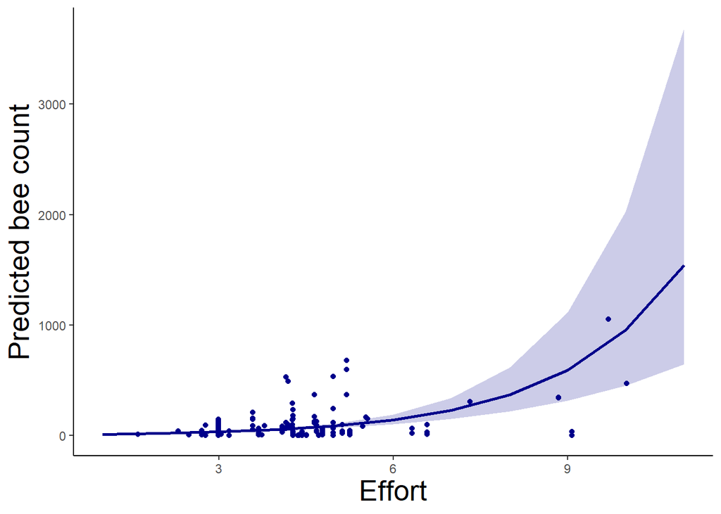

```r
# First plot the predicted counts based on the effort level, this is the natural logarithm regression line
ggplot(pred_effort, aes(x = x, y = predicted)) +
  geom_line(size = 1, col = "darkblue") + # make the plot a line
  # ribbon is the confidence interval. The data used here is the pred_effort, which has a column conf.low and conf.high. Alpha 0.2 gives the transparacy of the ribbon
  geom_ribbon(aes(ymin = conf.low, ymax = conf.high), alpha = 0.2, fill = "darkblue") +
  # Below points fromt the raw data is added to the plot.
  geom_point(data = bees,
             aes(x = effort, y = Eulaema_nigrita),
             col = "darkblue",
             inherit.aes = FALSE) +
  labs(x = "Effort",
       y = "Predicted bee count") +
  theme_classic() +
  theme(axis.title =element_text(size=20))
```

### MAT

```r
# Make the prediction with MAT as preditor and effort and altitude held constant
pred_MAT <-  ggpredict(m, terms = "MAT")
pred_MAT
```

```
## # Predicted counts of Eulaema_nigrita
##
## MAT | Predicted |         95% CI
## --------------------------------
## 135 |      2.29 |   0.58,   9.15
## 150 |      3.87 |   1.20,  12.51
## 170 |      7.79 |   3.19,  19.02
## 185 |     13.15 |   6.62,  26.11
## 200 |     22.19 |  13.66,  36.06
## 215 |     37.47 |  27.70,  50.68
## 230 |     63.27 |  52.09,  76.84
## 265 |    214.74 | 128.08, 360.05
##
## Adjusted for:
## *   effort =   4.16
## * altitude = 179.00
```

```
##
## Not all rows are shown in the output. Use `print(..., n = Inf)` to show
##   all rows.
```

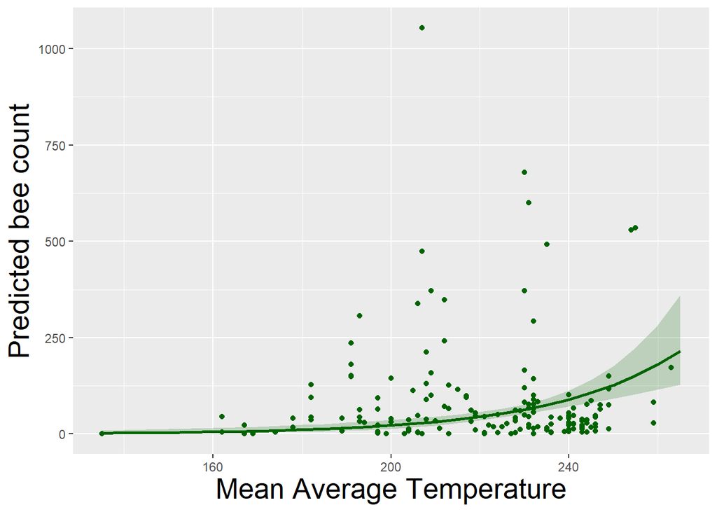

```r
# Plot the results
# Plot prediction
ggplot(pred_MAT, aes(x = x, y = predicted)) +
  geom_line(size = 1, col = "darkgreen") + # make the plot a line
  # Add confidence interval
  geom_ribbon(aes(ymin = conf.low, ymax = conf.high), alpha = 0.2, fill = "darkgreen") +
  # add raw data points
  geom_point(data = bees, aes(x = MAT, y = Eulaema_nigrita),
             inherit.aes = FALSE,
             col = "darkgreen") +
  labs(x = "Mean Average Temperature",
       y = "Predicted bee count") +
  theme(axis.title =element_text(size=20))
```

### Altitude

```r
# Make the prediction with altitude as predictor and effort and MAT held constant
pred_altitude <-  ggpredict(m, terms = "altitude")
pred_altitude
```

```
## # Predicted counts of Eulaema_nigrita
##
## altitude | Predicted |          95% CI
## --------------------------------------
##     -200 |     30.39 |  19.14,   48.26
##        0 |     43.13 |  31.77,   58.55
##      400 |     86.86 |  70.52,  106.98
##      600 |    123.25 |  87.98,  172.67
##      800 |    174.90 | 106.36,  287.62
##     1000 |    248.20 | 127.41,  483.51
##     1200 |    352.21 | 152.07,  815.76
##     1800 |   1006.48 | 256.52, 3948.99
##
## Adjusted for:
## * effort =   4.16
## *    MAT = 228.00
```

```
##
## Not all rows are shown in the output. Use `print(..., n = Inf)` to show
##   all rows.
```

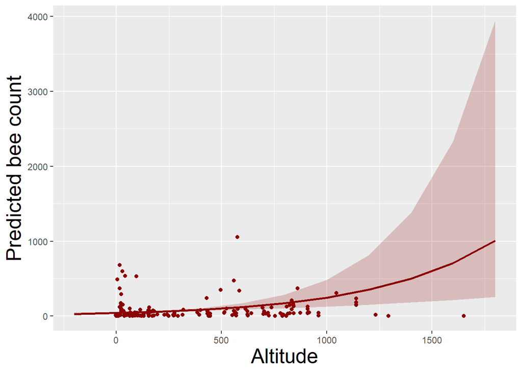

```r
# Plot the results
# Plot prediction
ggplot(pred_altitude, aes(x = x, y = predicted)) +
  geom_line(size = 1, col = "darkred") + # make the plot a line
  # Add confidence interval
  geom_ribbon(aes(ymin = conf.low, ymax = conf.high),
              alpha = 0.2, fill = "darkred") +
  # add raw data points
  geom_point(data = bees, aes(x = altitude, y = Eulaema_nigrita),
             inherit.aes = FALSE,
             col = "darkred") +
  labs(x = "Altitude",
       y = "Predicted bee count") +
  theme(axis.title =element_text(size=20))
```

Check residuals

[figure not shown]

```r
plot(m$deviance,m$null.deviance)
```